# Sonal_Kamble_Capstone_Final_Project_Notebook

**Business Context:**

A leading life-insurance company pays bonus amounts to its field agents based on their performance in terms of sales and customer interaction attributes. The company wants to better understand and manage the bonuses paid to its field agents. Understanding which agents will receive higher bonuses, and why, helps the business move from reactive, month-by-month reward decisions to a proactive approach that aligns incentives with measurable drivers of sales and customer behavior. This context matters because more targeted engagement and training for agents can improve sales effectiveness, reduce avoidable churn, and ensure the bonus budget is invested where it delivers the greatest business impact.

**Objective:**

As a data scientist at the life insurance company, you are tasked with building a model to predict agent bonuses based on customer and sales-related factors. This will help identify high-performing agents for tailored engagement programs and highlight those needing upskilling, ensuring that incentives and training efforts directly contribute to improved sales performance and efficient resource allocation.

**Data Description:**

CustID: Unique customer ID

AgentBonus: Bonus amount given to each agent in the last month

Age: Age of the customer

CustTenure: Tenure of the customer in the organization

Channel: Channel through which the acquisition of the customer is done

Occupation: Occupation of the customer

EducationField: Field of education of the customer

Gender: Gender of the customer

ExistingProdType: Existing product type of the customer

Designation: Designation of the customer in their organization

NumberOfPolicy: Total number of existing policies of a customer

MaritalStatus: Marital status of the customer

MonthlyIncome: Gross monthly income of the customer

Complaint: Indicator of complaints registered in the last month by the customer

ExistingPolicyTenure: Max tenure in all existing policies of the customer

SumAssured: Max of sum assured in all existing policies of the customer

Zone: Customer belongs to which zone in India? Like East, West, North, and South

PaymentMethod: Frequency of payment selected by customer, like Monthly, quarterly, half-yearly, and yearly

LastMonthCalls: Total calls attempted by the company to a customer for cross-sell

CustCareScore: Customer satisfaction score given by the customer in the previous service call

**Problem Understanding**

The business problem is to predict the bonus amount given to field agents based on their sales performance and customer-related attributes. The goal is to identify patterns that explain why some agents receive higher bonuses than others.

**Need of the study/project**

In the life insurance industry, field agents play a crucial role in driving sales and maintaining customer relationships. This study can help the company to analyze how different factors influence agent bonuses and to ensure that rewards are distributed in a fair, consistent, and performance-oriented manner.

By building a predictive model, the company can:

- Accurately forecast agent bonuses
- Recognize and retain high-performing agents
- Identify agents requiring training and performance improvement
- Improve sales effectiveness and customer engagement
- Support management in making strategic, data-driven decisions

**Understanding business/social opportunity**

Business opportunity in this project can give a business a key factors which are driving agent bonuses so the company can reward the right behaviors, improve customer targeting, and increase sales efficiency. It also helps reduce unnecessary effort and enables data-driven decision-making. From a social perspective, it ensures a fair and transparent bonus system for agents.

**Installing and Importing Necessary Libraries**

```python
import warnings
warnings.filterwarnings("ignore")

# Data handling
import numpy as np
import pandas as pd

# Train-test split
from sklearn.model_selection import train_test_split

# Visualization
import matplotlib.pyplot as plt
import seaborn as sns

# Display settings
pd.set_option("display.max_columns", None)
pd.set_option("display.max_rows", 100)

# Models
from sklearn.linear_model import LinearRegression
from sklearn.tree import DecisionTreeRegressor
from sklearn.ensemble import (
    BaggingRegressor,
    RandomForestRegressor,
    AdaBoostRegressor,
    GradientBoostingRegressor,
)

from xgboost import XGBRegressor

# Metrics (ONLY regression)
from sklearn.metrics import (
    r2_score,
    mean_squared_error,
    mean_absolute_error,
    mean_absolute_percentage_error,)

# Hyperparameter tuning
from sklearn.model_selection import GridSearchCV

# Scaling
from sklearn.preprocessing import StandardScaler
sc = StandardScaler()

import statsmodels.api as sm
```

**Loading the dataset**

```python
from google.colab import drive
drive.mount('/content/drive')
```

```python
data = pd.read_csv('/content/drive/MyDrive/InsuranceSales.csv')
```

```python
data = data.copy()
```

**Data Overview**

**First few rows of the dataset**

```python
data.head()
```

|  | CustID | AgentBonus | Age | CustTenure | Channel | Occupation | EducationField | Gender | ExistingProdType | Designation | NumberOfPolicy | MaritalStatus | MonthlyIncome | Complaint | ExistingPolicyTenure | SumAssured | Zone | PaymentMethod | LastMonthCalls | CustCareScore |
| --- | --- | --- | --- | --- | --- | --- | --- | --- | --- | --- | --- | --- | --- | --- | --- | --- | --- | --- | --- | --- |
| 0 | 7000000 | 4409 | 22.0 | 4.0 | Agent | Salaried | Graduate | Female | 3 | Manager | 2.0 | Single | 20993.0 | 1 | 2.0 | 806761.0 | North | Half Yearly | 5 | 2.0 |
| 1 | 7000001 | 2214 | 11.0 | 2.0 | Third Party Partner | Salaried | Graduate | Male | 4 | Manager | 4.0 | Divorced | 20130.0 | 0 | 3.0 | 294502.0 | North | Yearly | 7 | 3.0 |
| 2 | 7000002 | 4273 | 26.0 | 4.0 | Agent | Free Lancer | Post Graduate | Male | 4 | Exe | 3.0 | Unmarried | 17090.0 | 1 | 2.0 | NaN | North | Yearly | 0 | 3.0 |
| 3 | 7000003 | 1791 | 11.0 | NaN | Third Party Partner | Salaried | Graduate | Fe male | 3 | Executive | 3.0 | Divorced | 17909.0 | 1 | 2.0 | 268635.0 | West | Half Yearly | 0 | 5.0 |
| 4 | 7000004 | 2955 | 6.0 | NaN | Agent | Small Business | UG | Male | 3 | Executive | 4.0 | Divorced | 18468.0 | 0 | 4.0 | 366405.0 | West | Half Yearly | 2 | 5.0 |

**Last few rows of the dataset**

```python
data.tail()
```

|  | CustID | AgentBonus | Age | CustTenure | Channel | Occupation | EducationField | Gender | ExistingProdType | Designation | NumberOfPolicy | MaritalStatus | MonthlyIncome | Complaint | ExistingPolicyTenure | SumAssured | Zone | PaymentMethod | LastMonthCalls | CustCareScore |
| --- | --- | --- | --- | --- | --- | --- | --- | --- | --- | --- | --- | --- | --- | --- | --- | --- | --- | --- | --- | --- |
| 4515 | 7004515 | 3953 | 4.0 | 8.0 | Agent | Small Business | Graduate | Male | 4 | Senior Manager | 2.0 | Single | 26355.0 | 0 | 2.0 | 636473.0 | West | Yearly | 9 | 1.0 |
| 4516 | 7004516 | 2939 | 9.0 | 9.0 | Agent | Salaried | Under Graduate | Female | 2 | Executive | 2.0 | Married | 20991.0 | 0 | 3.0 | 296813.0 | North | Yearly | 1 | 3.0 |
| 4517 | 7004517 | 3792 | 23.0 | 23.0 | Agent | Salaried | Engineer | Female | 5 | AVP | 5.0 | Single | NaN | 0 | 2.0 | 667371.0 | North | Half Yearly | 4 | 1.0 |
| 4518 | 7004518 | 4816 | 10.0 | 10.0 | Online | Small Business | Graduate | Female | 4 | Executive | 2.0 | Single | 20068.0 | 0 | 6.0 | 943999.0 | West | Half Yearly | 1 | 5.0 |
| 4519 | 7004519 | 4764 | 14.0 | 10.0 | Agent | Salaried | Under Graduate | Female | 5 | Manager | 2.0 | Married | 23820.0 | 0 | 3.0 | 700308.0 | North | Half Yearly | 1 | 3.0 |

**Shape of the Dataset**

```python
data.shape
```

```
(4520, 20)
```

- There are 4520 rows and 20 columns in the dataset.

**Data types of the columns for the dataset**

```python
data.info()
```

```
<class 'pandas.core.frame.DataFrame'>
RangeIndex: 4520 entries, 0 to 4519
Data columns (total 20 columns):
 #   Column                Non-Null Count  Dtype
---  ------                --------------  -----
 0   CustID                4520 non-null   int64
 1   AgentBonus            4520 non-null   int64
 2   Age                   4251 non-null   float64
 3   CustTenure            4294 non-null   float64
 4   Channel               4520 non-null   object
 5   Occupation            4520 non-null   object
 6   EducationField        4520 non-null   object
 7   Gender                4520 non-null   object
 8   ExistingProdType      4520 non-null   int64
 9   Designation           4520 non-null   object
 10  NumberOfPolicy        4475 non-null   float64
 11  MaritalStatus         4520 non-null   object
 12  MonthlyIncome         4284 non-null   float64
 13  Complaint             4520 non-null   int64
 14  ExistingPolicyTenure  4336 non-null   float64
 15  SumAssured            4366 non-null   float64
 16  Zone                  4520 non-null   object
 17  PaymentMethod         4520 non-null   object
 18  LastMonthCalls        4520 non-null   int64
 19  CustCareScore         4468 non-null   float64
dtypes: float64(7), int64(5), object(8)
memory usage: 706.4+ KB
```

- Dataset has 12 numerics and 8 data types columns in the data.

**Statistical summary of the dataset**

```python
data.describe()
```

|  | CustID | AgentBonus | Age | CustTenure | ExistingProdType | NumberOfPolicy | MonthlyIncome | Complaint | ExistingPolicyTenure | SumAssured | LastMonthCalls | CustCareScore |
| --- | --- | --- | --- | --- | --- | --- | --- | --- | --- | --- | --- | --- |
| count | 4.520000e+03 | 4520.000000 | 4251.000000 | 4294.000000 | 4520.000000 | 4475.000000 | 4284.000000 | 4520.000000 | 4336.000000 | 4.366000e+03 | 4520.000000 | 4468.000000 |
| mean | 7.002260e+06 | 4077.838274 | 14.494707 | 14.469027 | 3.688938 | 3.565363 | 22890.309991 | 0.287168 | 4.130074 | 6.199997e+05 | 4.626991 | 3.067592 |
| std | 1.304956e+03 | 1403.321711 | 9.037629 | 8.963671 | 1.015769 | 1.455926 | 4885.600757 | 0.452491 | 3.346386 | 2.462348e+05 | 3.620132 | 1.382968 |
| min | 7.000000e+06 | 1605.000000 | 2.000000 | 2.000000 | 1.000000 | 1.000000 | 16009.000000 | 0.000000 | 1.000000 | 1.685360e+05 | 0.000000 | 1.000000 |
| 25% | 7.001130e+06 | 3027.750000 | 7.000000 | 7.000000 | 3.000000 | 2.000000 | 19683.500000 | 0.000000 | 2.000000 | 4.394432e+05 | 2.000000 | 2.000000 |
| 50% | 7.002260e+06 | 3911.500000 | 13.000000 | 13.000000 | 4.000000 | 4.000000 | 21606.000000 | 0.000000 | 3.000000 | 5.789765e+05 | 3.000000 | 3.000000 |
| 75% | 7.003389e+06 | 4867.250000 | 20.000000 | 20.000000 | 4.000000 | 5.000000 | 24725.000000 | 1.000000 | 6.000000 | 7.582360e+05 | 8.000000 | 4.000000 |
| max | 7.004519e+06 | 9608.000000 | 58.000000 | 57.000000 | 6.000000 | 6.000000 | 38456.000000 | 1.000000 | 25.000000 | 1.838496e+06 | 18.000000 | 5.000000 |

- The average agent bonus is 4077 while minimum is 1605 and maximum is 9608.
- Age has an average of 14.49.
- CustTenure averages 14.46, ranging from 2 years to 57 years.
- MonthlyIncome has an average of 22,890, minimum 16,009, and maximum 38,456.
- NumberOfPolicy averages 3.56, with values between 1 and 6.
- SumAssured has an average of 6.2 lakh, minimum 1.68 lakh, and maximum 18.38 lakh.

**Checking for duplicate values**

```python
data.duplicated().sum()
```

```
np.int64(0)
```

- There are no duplicate values present in the data.

**Checking for missing values**

```python
data.isnull().sum()
```

|  | 0 |
| --- | --- |
| CustID | 0 |
| AgentBonus | 0 |
| Age | 269 |
| CustTenure | 226 |
| Channel | 0 |
| Occupation | 0 |
| EducationField | 0 |
| Gender | 0 |
| ExistingProdType | 0 |
| Designation | 0 |
| NumberOfPolicy | 45 |
| MaritalStatus | 0 |
| MonthlyIncome | 236 |
| Complaint | 0 |
| ExistingPolicyTenure | 184 |
| SumAssured | 154 |
| Zone | 0 |
| PaymentMethod | 0 |
| LastMonthCalls | 0 |
| CustCareScore | 52 |

**dtype:** int64

- The dataset has missing values.

**Data Cleaning**

```python
#Removing customer ID which is not necessary for further review
data = data.drop('CustID', axis = 1)
```

**In the dataset observed some discripancies in the gender column and occupation column which can be covered before EDA.**

```python
#checking unique values in gender
data['Gender'].unique()
```

```
array(['Female', 'Male', 'Fe male'], dtype=object)
```

```python
#checking the count of unique values
data['Gender'].value_counts()
```

| Gender | count |
| --- | --- |
| Male | 2688 |
| Female | 1507 |
| Fe male | 325 |

**dtype:** int64

```python
#replacing fe male with the value Female as its incorrect
data['Gender'] = data['Gender'].replace('fe male','Female')
```

```python
data['Gender'].unique()
```

```
array(['Female', 'Male', 'Fe male'], dtype=object)
```

```python
data['Gender'] = data['Gender'].str.strip().str.title()
```

```python
data['Gender'] = data['Gender'].replace('Fe Male', 'Female')
```

```python
data['Gender'].unique()
```

```
array(['Female', 'Male'], dtype=object)
```

**We have replaced the Fe male with female now the gender column is good lets treat occupation column where it seems to be an typo in Laarge Business.**

```python
#correcting the typo in occupation column
data['Occupation'] = data['Occupation'].replace('Laarge Business', 'Large Business')
```

```python
data['Occupation'].unique()
```

```
array(['Salaried', 'Free Lancer', 'Small Business', 'Large Business'],
      dtype=object)
```

**Also i have observed typo error in designation we have two groups which is exe and executive they seems to be the same treating this as well.**

```python
#Replacing the exe in designation to executive
data['Designation'] = data['Designation'].replace('Exe', 'Executive')
```

```python
print(data['Designation'].unique())
```

```
['Manager' 'Executive' 'VP' 'AVP' 'Senior Manager']
```

**Exploratory Data Analysis (EDA)**

```python
def histogram_boxplot(data, feature, figsize=(15, 10), kde=False, bins=None):
    """
    Boxplot and histogram combined

    data: dataframe
    feature: dataframe column
    figsize: size of figure (default (15,10))
    kde: whether to show the density curve (default False)
    bins: number of bins for histogram (default None)
    """
    f2, (ax_box2, ax_hist2) = plt.subplots(
        nrows=2,  # Number of rows of the subplot grid= 2
        sharex=True,  # x-axis will be shared among all subplots
        gridspec_kw={"height_ratios": (0.25, 0.75)},
        figsize=figsize,
    )  # creating the 2 subplots
    sns.boxplot(
        data=data, x=feature, ax=ax_box2, showmeans=True, color="violet"
    )  # boxplot will be created and a triangle will indicate the mean value of the column
    sns.histplot(
        data=data, x=feature, kde=kde, ax=ax_hist2, bins=bins
    ) if bins else sns.histplot(
        data=data, x=feature, kde=kde, ax=ax_hist2
    )  # For histogram
    ax_hist2.axvline(
        data[feature].mean(), color="green", linestyle="--"
    )  # Add mean to the histogram
    ax_hist2.axvline(
        data[feature].median(), color="black", linestyle="-"
    )  # Add median to the histogram
```

```python
# function to create labeled barplots


def labeled_barplot(data, feature, perc=False, n=None):
    """
    Barplot with percentage at the top

    data: dataframe
    feature: dataframe column
    perc: whether to display percentages instead of count (default is False)
    n: displays the top n category levels (default is None, i.e., display all levels)
    """

    total = len(data[feature])  # length of the column
    count = data[feature].nunique()
    if n is None:
        plt.figure(figsize=(count + 2, 6))
    else:
        plt.figure(figsize=(n + 2, 6))

    plt.xticks(rotation=90, fontsize=15)
    ax = sns.countplot(
        data=data,
        x=feature,
        hue=feature,
        palette="Paired",
        order=data[feature].value_counts().index[:n],
    )

    for p in ax.patches:
        if perc == True:
            label = "{:.1f}%".format(
                100 * p.get_height() / total
            )  # percentage of each class of the category
        else:
            label = p.get_height()  # count of each level of the category

        x = p.get_x() + p.get_width() / 2  # width of the plot
        y = p.get_height()  # height of the plot

        ax.annotate(
            label,
            (x, y),
            ha="center",
            va="center",
            size=12,
            xytext=(0, 5),
            textcoords="offset points",
        )  # annotate the percentage

    plt.show()  # show the plot
```

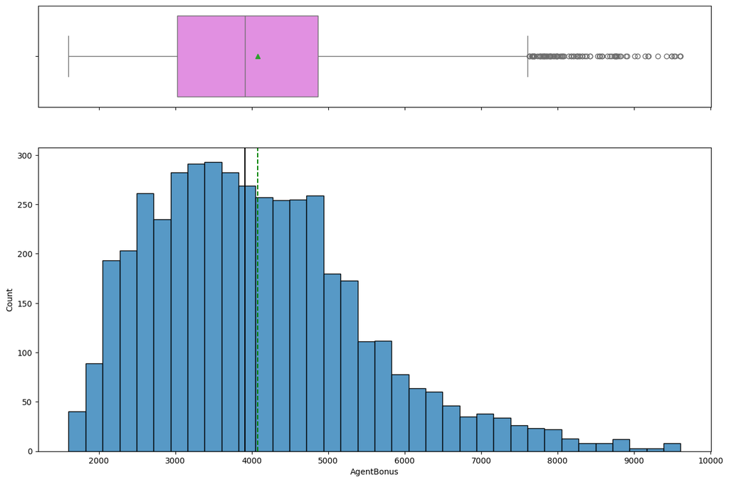

```python
#plotting histogram and boxplot for variable bonus
histogram_boxplot(data, 'AgentBonus')
```

- The distribution is right skewed and most of the values lies between 2,500 to 5,000 has a long tail towards a higher value upto 9,500.
- There are many outliers are present but they seems to be realistic because if some of the agents performance is high they can earn high bonus.

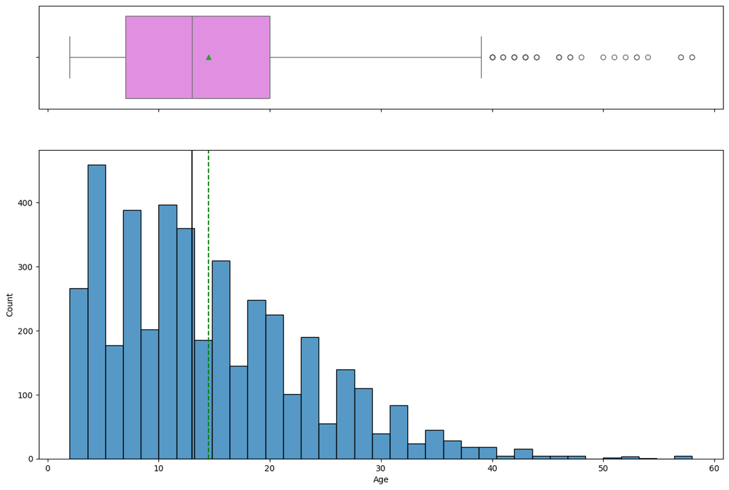

```python
#plotting histogram and boxplot for variable age
histogram_boxplot(data, 'Age')
```

- The distribution is right skewed, most of the customer has lower age range between 5 - 20.
- Long tail towards higher age upto 60 and has outliers.
- Very low age (5- 18) seems suspicious and unrealistic, that can also be Policies taken by parents for children so validating the data and not removing outliers because they seems unrealistic.

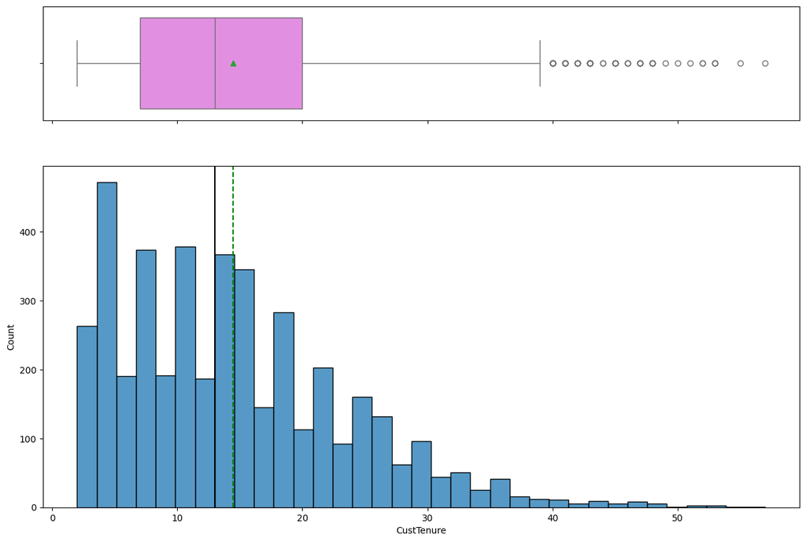

```python
#plotting histogram and boxplot for variable customer tenure
histogram_boxplot(data, 'CustTenure')
```

- The distribution is right skewed, most of the customer have tenure between 5 to 20. Observed a long tail exceeding upto 55.
- Some customers have upto 55 years of tenure and it seems to be realistic as the company can be very old or maybe customer have joined very early so not removing outliers.

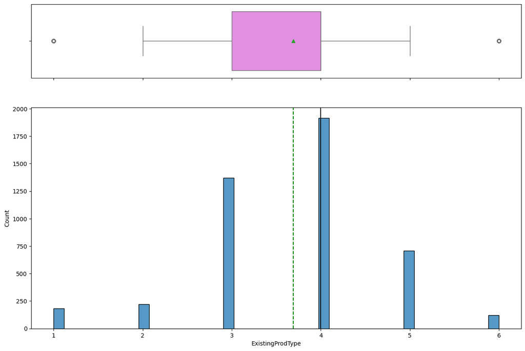

```python
#plotting histogram and boxplot for variable existing prod type
histogram_boxplot(data, 'ExistingProdType')
```

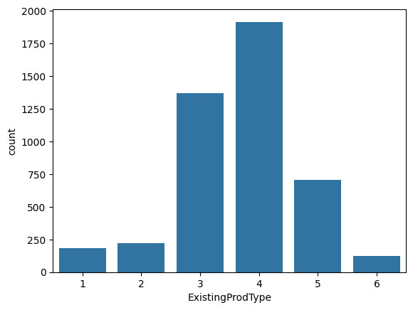

```python
sns.countplot(x='ExistingProdType', data=data)
```

**Countplot was more appropriate to understand its distribution instead of boxplot because ExistingProdType is categorical, boxplot can be misleading.**

**Observation:**

- Product type 4 has the highest count followed by product type 3.

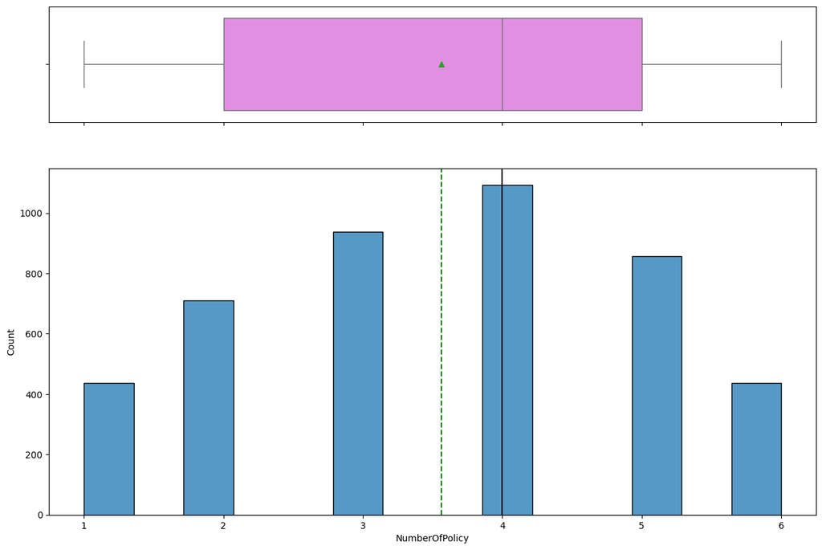

```python
#plotting histogram and boxplot for variable number of policy
histogram_boxplot(data, 'NumberOfPolicy')
```

- The distribution is slightly left skewed, highest number of policies across the customers.
- No outliers present.

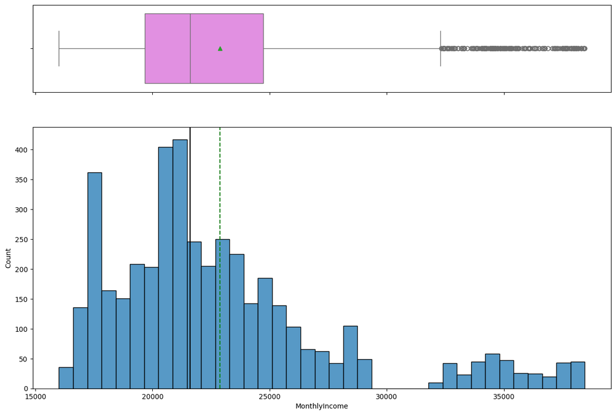

```python
#plotting histogram and boxplot for variable monthly income
histogram_boxplot(data, 'MonthlyIncome')
```

- The distribution is rightly skewed with a long tail stretching toward the right.
- High income range falls within 20000 to 25000
- High-income outliers ranging from approximately 32,000 to 38,000.
- Keeping those outliers as they are realistic outliers.

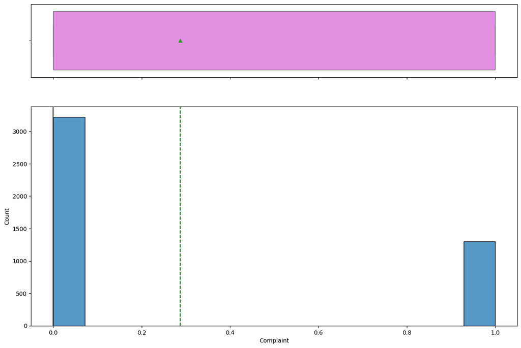

```python
#plotting histogram and boxplot for variable complaint
histogram_boxplot(data, 'Complaint')
```

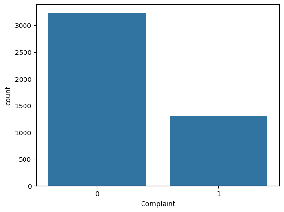

```python
sns.countplot(x='Complaint', data=data)
```

- The majority of the customers did not made any compaints.

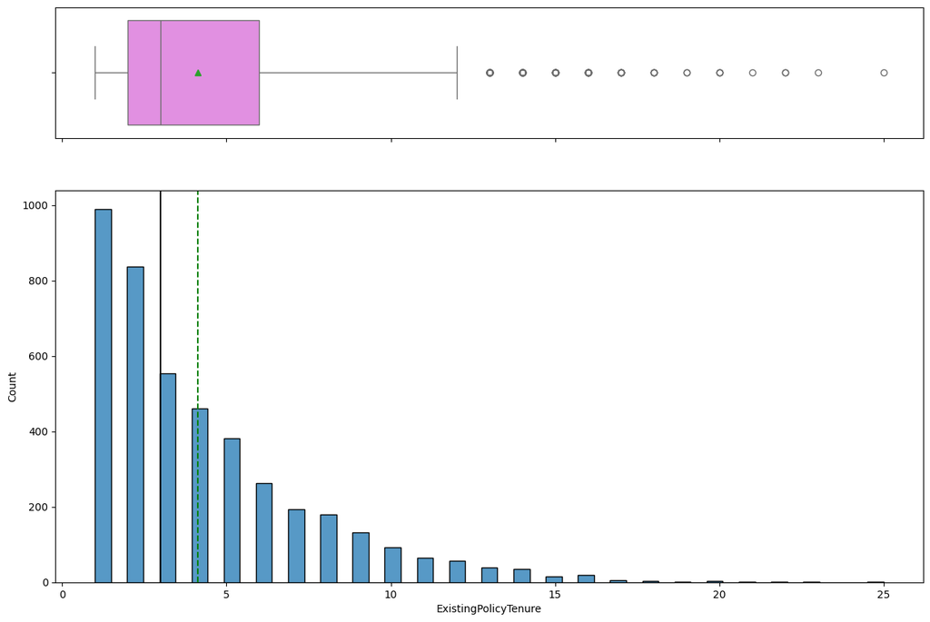

```python
#plotting histogram and boxplot for variable existing policy tenure
histogram_boxplot(data, 'ExistingPolicyTenure')
```

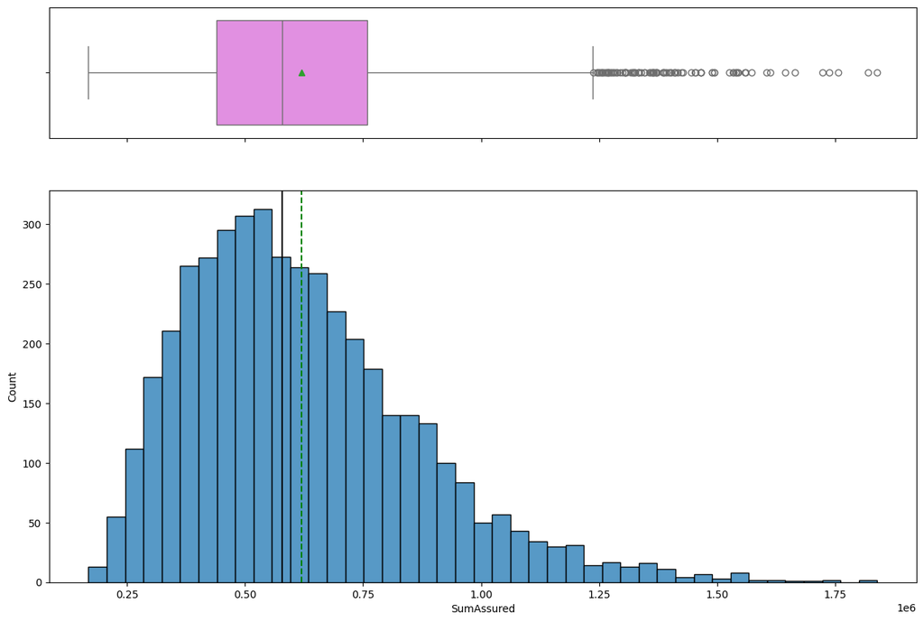

```python
#plotting histogram and boxplot for variable sum assured
histogram_boxplot(data, 'SumAssured')
```

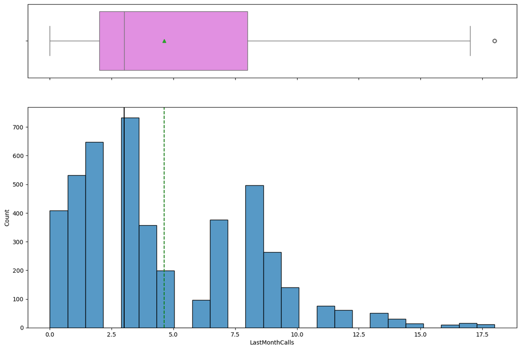

```python
#plotting histogram and boxplot for variable last month calls
histogram_boxplot(data, 'LastMonthCalls')
```

- The distribution is slightly right skewed, showing a high peak around 3 calls and secondary surge near 8 calls.
- The boxplot confirms one outliers reaching 18 calls.

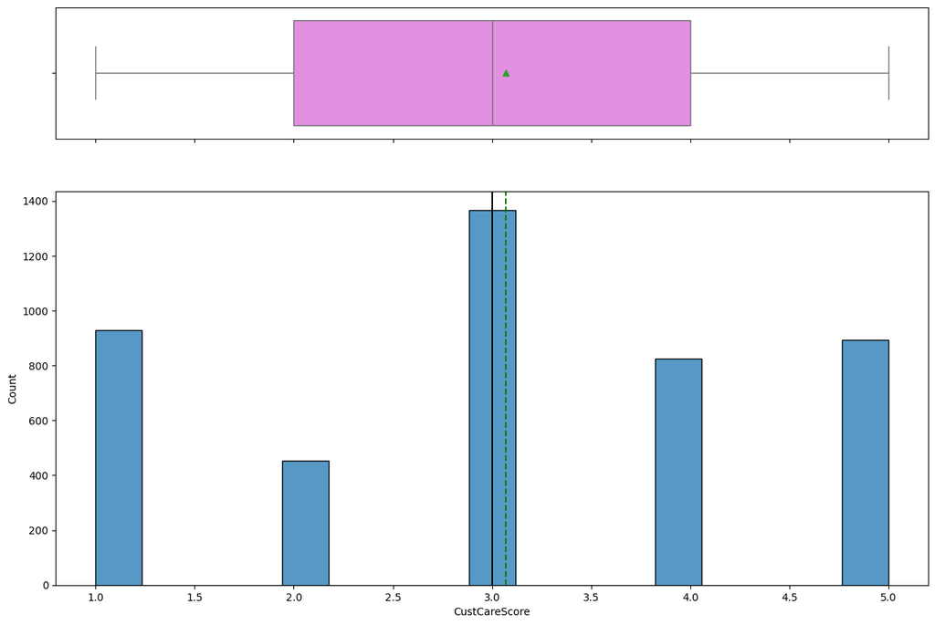

```python
#plotting histogram and boxplot for variable customer care score
histogram_boxplot(data, 'CustCareScore')
```

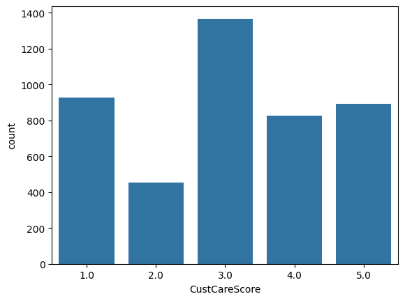

```python
sns.countplot(x='CustCareScore', data=data)
```

- The plot shows discrete distribution with the highest concentration score on 3.
- The boxplot shows a symmetric interquartile range (IQR) between scores 2 and 4, with no outliers detected.

**Univariate analysis of Categorical Variables**

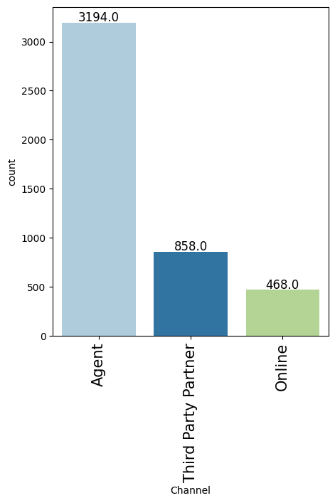

```python
#creating labled barplot for the variable channel
labeled_barplot(data, 'Channel')
```

- Agent channel is dominant source of interaction, with the count of 3,194.
- For third party Partner and Online channel the value count is lower.

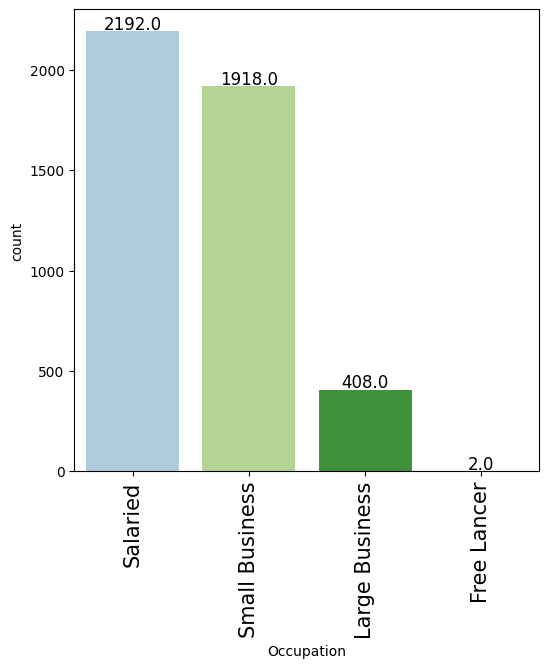

```python
#creating labled barplot for the variable occupation
labeled_barplot(data, 'Occupation')
```

- In the dataset the largest portion of customers are salaried (2,192) and have small business (1,918).

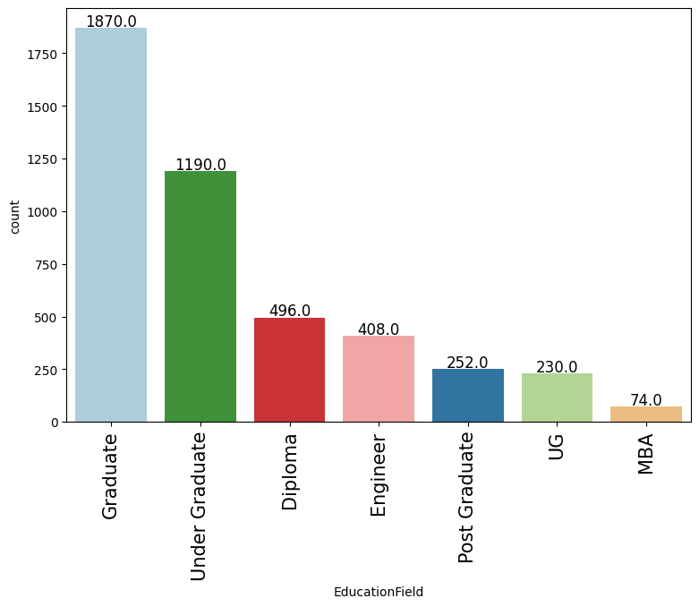

```python
#creating labled barplot for the variable occupation education field
labeled_barplot(data, 'EducationField')
```

- The vast majority of the customers consists of Graduates (1,870) and Under Graduates (1,190).

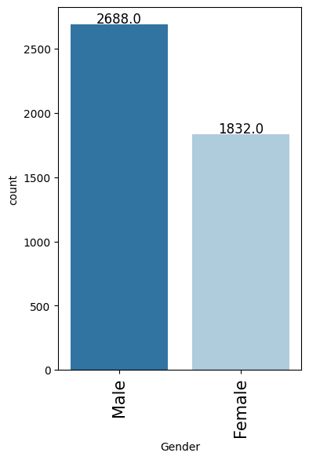

```python
#creating labled barplot for the variable gender
labeled_barplot(data, 'Gender')
```

- The majority of the customers who buying policies are Male category followed by female category.

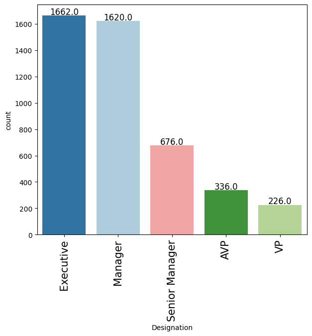

```python
#creating labled barplot for the variable designation
labeled_barplot(data, 'Designation')
```

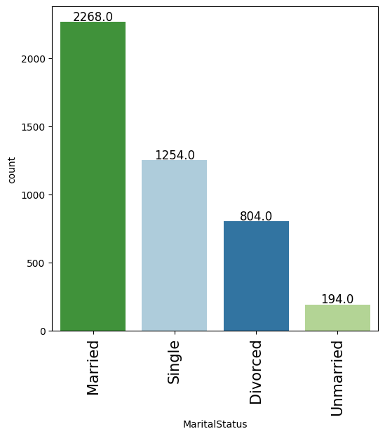

```python
#creating labled barplot for the variable marital status
labeled_barplot(data, 'MaritalStatus')
```

- Most of the customers are married with the count of 2,268 followed by single with count 1,254.
- Divorced (804) and Unmarried (194) customers have significantly lower count.

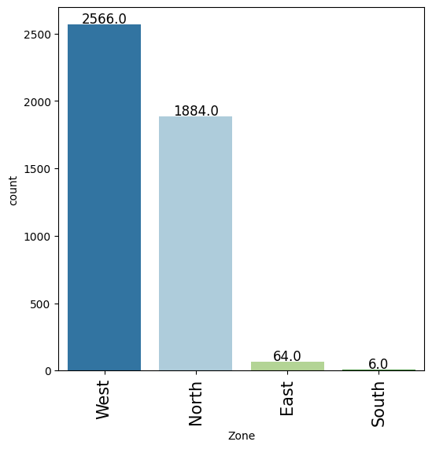

```python
#creating labled barplot for the variable zone
labeled_barplot(data, 'Zone')
```

- The dataset is heavily concentrated on West (2,566) and North (1,884) zones.
- For east (64.0) and South (6.0) zones counts are lower.

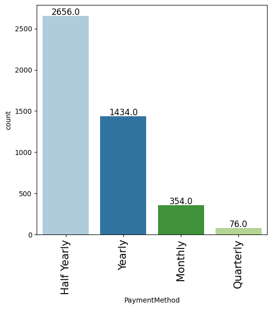

```python
#creating labled barplot for the variable payment method
labeled_barplot(data, 'PaymentMethod')
```

- Most of the customers are choosing payment method as half yearly with the count of 2,656 followed by Yearly with count 1,434.

**Bivariate Analysis**

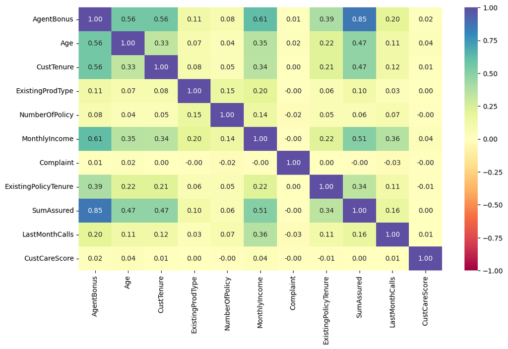

```python
num_cols = data.select_dtypes(include=np.number).columns.tolist()
plt.figure(figsize=(12, 7))
sns.heatmap(
    data[num_cols].corr(), annot=True, vmin=-1, vmax=1, fmt=".2f", cmap="Spectral"
)
plt.show()
```

- AgentBonus has strongly correlated with SumAssured (0.85)
- Secondly agent bonus is also correlated with MonthlyIncome (0.61), Age (0.56), and CustTenure (0.56).
- Monthly income and sum assured is correlated with each other as the customer having high income are particularly choosing policies with higher sum assured.
- Customer care score, number of policy and last month calls has lower correlation.

**Bivariate analyisis of Target variable vs numerical variable**

**Age vs AgentBonus**

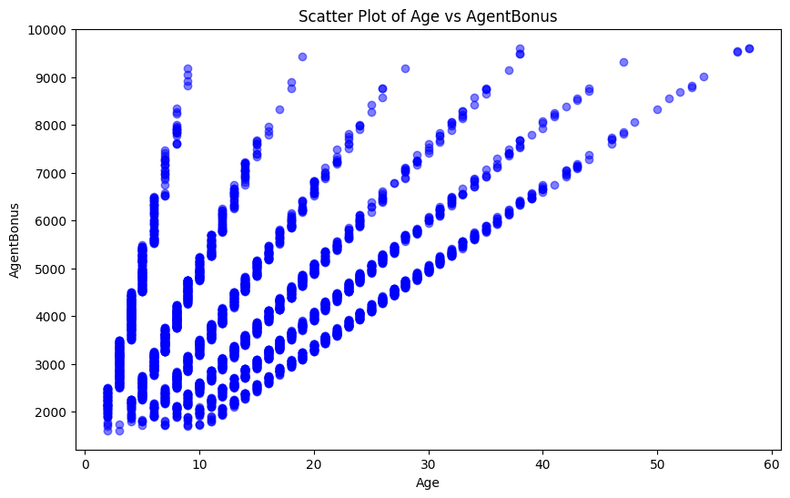

```python
#using scatterplot for the for the numeric variables age and agent bonus
plt.figure(figsize=(10, 6))
plt.scatter(data['Age'], data['AgentBonus'], alpha=0.5, color='blue')
plt.title('Scatter Plot of Age vs AgentBonus')
plt.xlabel('Age')
plt.ylabel('AgentBonus')
plt.show()
```

**CustTenure vs AgentBonus**

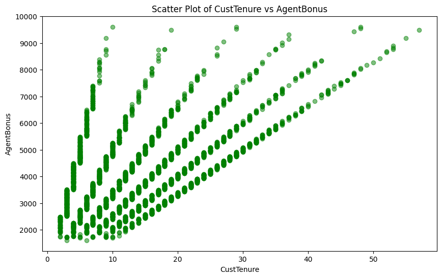

```python
#using scatterplot for the for the numeric variables CustTenure and agent bonus
plt.figure(figsize=(10,6))
plt.scatter(data['CustTenure'], data['AgentBonus'], alpha=0.5, color='green')
plt.title('Scatter Plot of CustTenure vs AgentBonus')
plt.xlabel('CustTenure')
plt.ylabel('AgentBonus')
plt.show()
```

**SumAssured vs AgentBonus**

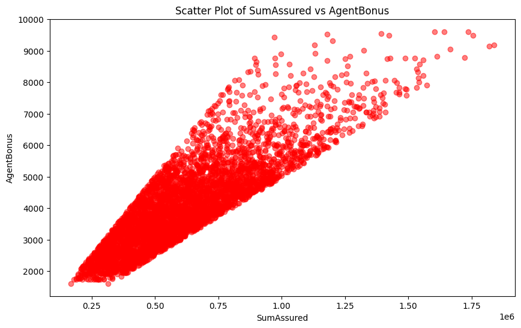

```python
#using scatterplot for the for the numeric variables cust tenure and agent bonus
plt.figure(figsize=(10,6))
plt.scatter(data['SumAssured'], data['AgentBonus'], alpha=0.5, color='red')
plt.title('Scatter Plot of SumAssured vs AgentBonus')
plt.xlabel('SumAssured')
plt.ylabel('AgentBonus')
plt.show()
```

**Monthly Income Vs AgentBonus**

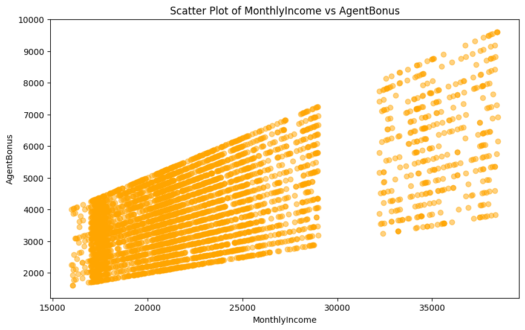

```python
#using scatterplot for the for the numeric variables Monthly income and agent bonus
plt.figure(figsize=(10,6))
plt.scatter(data['MonthlyIncome'], data['AgentBonus'], alpha=0.5, color='orange')
plt.title('Scatter Plot of MonthlyIncome vs AgentBonus')
plt.xlabel('MonthlyIncome')
plt.ylabel('AgentBonus')
plt.show()
```

- There is a clear positive relationship as the monthly income increases agent bonus increases.
- Points form an upward pattern.
- The most data is grouped between income 18,000 to 25,000.
- For higher income values above 30,000 the agent bonus is gignificantly higher.

**Bivariate analysis of Target Variable vs categorical variables**

**I think for the project below can be the important categorical variables to plot with target variable.**

**Channel Vs AgentBonus**

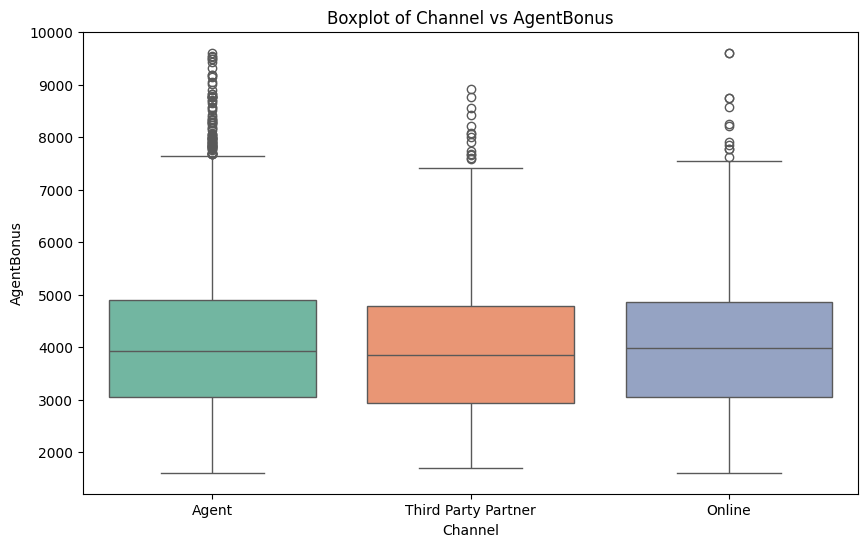

```python
#Creating boxplot for the variables like channel and agent bonus
plt.figure(figsize=(10,6))
sns.boxplot(x='Channel', y='AgentBonus', data=data, palette='Set2')
plt.title('Boxplot of Channel vs AgentBonus')
plt.xlabel('Channel')
plt.ylabel('AgentBonus')
plt.show()
```

**Occupation Vs AgentBonus**

```
<module 'matplotlib.pyplot' from '/usr/local/lib/python3.12/dist-packages/matplotlib/pyplot.py'>
```

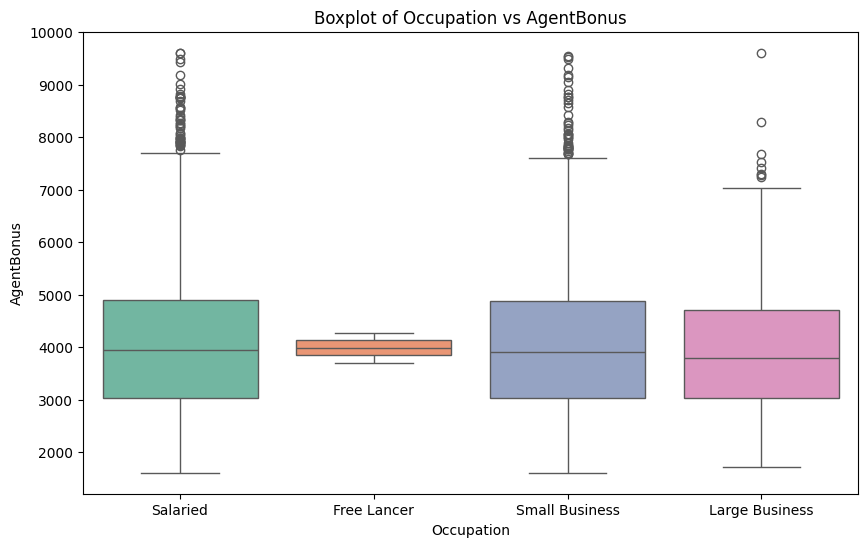

```python
#Creating boxplot for the variables like occupation and agent bonus
plt.figure(figsize=(10,6))
sns.boxplot(x='Occupation', y='AgentBonus', data=data, palette='Set2')
plt.title('Boxplot of Occupation vs AgentBonus')
plt.xlabel('Occupation')
plt.ylabel('AgentBonus')
plt
```

**Designation Vs AgentBonus**

```
<module 'matplotlib.pyplot' from '/usr/local/lib/python3.12/dist-packages/matplotlib/pyplot.py'>
```

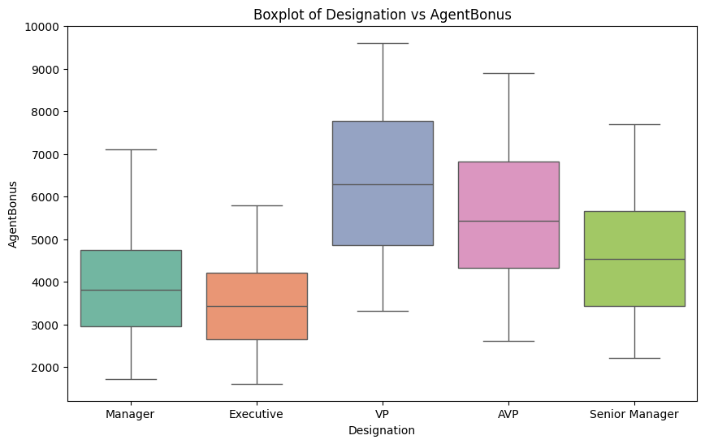

```python
#Creating boxplot for the variables like designation and agent bonus
plt.figure(figsize=(10,6))
sns.boxplot(x='Designation', y='AgentBonus', data=data, palette='Set2')
plt.title('Boxplot of Designation vs AgentBonus')
plt.xlabel('Designation')
plt.ylabel('AgentBonus')
plt
```

- VP and AVP has the highest median, followed by senier manager.
- The customers with designation manager and executive shows lower median bonuses aouund 3,500 and 4,000.

**We have completed the EDA, Univariate, Bivariate and Multivariate analysis. Now lets proceed further preprocessing the data and model building.**

**Data Preprocessing**

**1. Duplicate value check and treatment**

```python
#Cheacking duplicates in the dataset if any
data.duplicated().sum()
```

```
np.int64(0)
```

- There are no duplicates present in the data.

**2. Anomalous value check and treatment**

```python
#checking the customer age below 18
data[data['Age'] < 18]
```

|  | AgentBonus | Age | CustTenure | Channel | Occupation | EducationField | Gender | ExistingProdType | Designation | NumberOfPolicy | MaritalStatus | MonthlyIncome | Complaint | ExistingPolicyTenure | SumAssured | Zone | PaymentMethod | LastMonthCalls | CustCareScore |
| --- | --- | --- | --- | --- | --- | --- | --- | --- | --- | --- | --- | --- | --- | --- | --- | --- | --- | --- | --- |
| 1 | 2214 | 11.0 | 2.0 | Third Party Partner | Salaried | Graduate | Male | 4 | Manager | 4.0 | Divorced | 20130.0 | 0 | 3.0 | 294502.0 | North | Yearly | 7 | 3.0 |
| 3 | 1791 | 11.0 | NaN | Third Party Partner | Salaried | Graduate | Female | 3 | Executive | 3.0 | Divorced | 17909.0 | 1 | 2.0 | 268635.0 | West | Half Yearly | 0 | 5.0 |
| 4 | 2955 | 6.0 | NaN | Agent | Small Business | UG | Male | 3 | Executive | 4.0 | Divorced | 18468.0 | 0 | 4.0 | 366405.0 | West | Half Yearly | 2 | 5.0 |
| 5 | 3252 | 7.0 | NaN | Third Party Partner | Salaried | Graduate | Male | 3 | Executive | 2.0 | Single | 18068.0 | 0 | 2.0 | 487836.0 | North | Half Yearly | 6 | 5.0 |
| 6 | 3850 | 12.0 | 23.0 | Agent | Salaried | Graduate | Male | 4 | VP | 3.0 | Divorced | 34999.0 | 0 | 2.0 | 392689.0 | North | Yearly | 9 | 2.0 |
| ... | ... | ... | ... | ... | ... | ... | ... | ... | ... | ... | ... | ... | ... | ... | ... | ... | ... | ... | ... |
| 4514 | 2541 | 10.0 | 3.0 | Third Party Partner | Salaried | Diploma | Female | 2 | Manager | 6.0 | Married | 23096.0 | 0 | 5.0 | 276921.0 | West | Yearly | 14 | 5.0 |
| 4515 | 3953 | 4.0 | 8.0 | Agent | Small Business | Graduate | Male | 4 | Senior Manager | 2.0 | Single | 26355.0 | 0 | 2.0 | 636473.0 | West | Yearly | 9 | 1.0 |
| 4516 | 2939 | 9.0 | 9.0 | Agent | Salaried | Under Graduate | Female | 2 | Executive | 2.0 | Married | 20991.0 | 0 | 3.0 | 296813.0 | North | Yearly | 1 | 3.0 |
| 4518 | 4816 | 10.0 | 10.0 | Online | Small Business | Graduate | Female | 4 | Executive | 2.0 | Single | 20068.0 | 0 | 6.0 | 943999.0 | West | Half Yearly | 1 | 5.0 |
| 4519 | 4764 | 14.0 | 10.0 | Agent | Salaried | Under Graduate | Female | 5 | Manager | 2.0 | Married | 23820.0 | 0 | 3.0 | 700308.0 | North | Half Yearly | 1 | 3.0 |

2887 rows × 19 columns

```python
(data['Age'] < 18).sum()
```

```
np.int64(2887)
```

**During anomalous value analysis, lower age values were observed. However, these values accounted for a substantial portion of the dataset (~3000 records) and are logically valid in the insurance context, where policies may be issued to minors. Therefore, these observations were retained to avoid loss of meaningful information.**

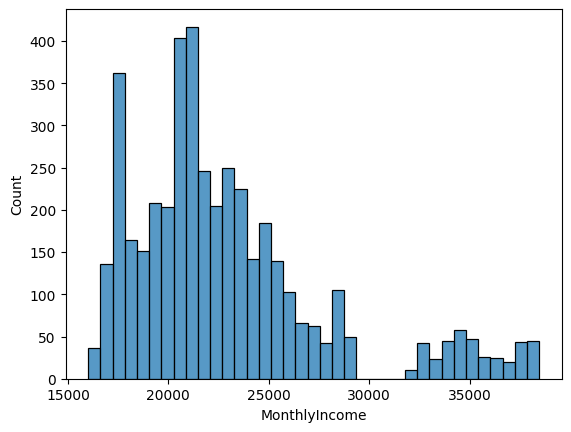

```python
#creating the histplot for the variable monthly income
sns.histplot(x='MonthlyIncome', data=data)
```

**Also some high values are observed in monthly income and sum assured but can be realistic because individuals can be high earning and also the policies with high sum assured.** |

**3. Missing value check and treatment**

```python
#checking missing value count
data.isnull().sum()
```

|  | 0 |
| --- | --- |
| AgentBonus | 0 |
| Age | 269 |
| CustTenure | 226 |
| Channel | 0 |
| Occupation | 0 |
| EducationField | 0 |
| Gender | 0 |
| ExistingProdType | 0 |
| Designation | 0 |
| NumberOfPolicy | 45 |
| MaritalStatus | 0 |
| MonthlyIncome | 236 |
| Complaint | 0 |
| ExistingPolicyTenure | 184 |
| SumAssured | 154 |
| Zone | 0 |
| PaymentMethod | 0 |
| LastMonthCalls | 0 |
| CustCareScore | 52 |

**dtype:** int64

```python
#Filling the missing values in age using median function
data['Age'] = data['Age'].fillna(data['Age'].median())
```

```python
#Using median for filling up missing values in custtenure, Numberofpolicy, monthlyincome, existing policytenure, sumassured, custcarescore
num_cols = ['CustTenure','NumberOfPolicy','MonthlyIncome','ExistingPolicyTenure','SumAssured','CustCareScore']
for col in num_cols:
    data[col] = data[col].fillna(data[col].median())
```

```python
#Checking missing values again
data.isnull().sum()
```

|  | 0 |
| --- | --- |
| AgentBonus | 0 |
| Age | 0 |
| CustTenure | 0 |
| Channel | 0 |
| Occupation | 0 |
| EducationField | 0 |
| Gender | 0 |
| ExistingProdType | 0 |
| Designation | 0 |
| NumberOfPolicy | 0 |
| MaritalStatus | 0 |
| MonthlyIncome | 0 |
| Complaint | 0 |
| ExistingPolicyTenure | 0 |
| SumAssured | 0 |
| Zone | 0 |
| PaymentMethod | 0 |
| LastMonthCalls | 0 |
| CustCareScore | 0 |

**dtype:** int64

- Missing values are treated using median for numrical variables.

**4. Outlier check and treatment**

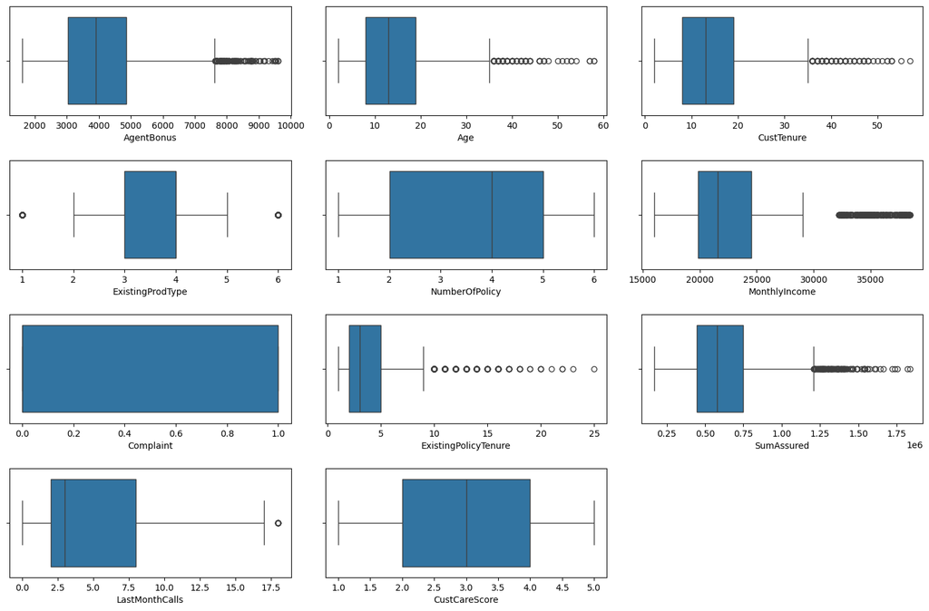

```python
import math

# outlier detection using boxplot
num_cols = data.select_dtypes(include=np.number).columns.tolist()
n = len(num_cols)

cols = 3
rows = math.ceil(n / cols)

plt.figure(figsize=(15, 10))

for i, variable in enumerate(num_cols):
    plt.subplot(rows, cols, i+1)
    sns.boxplot(data=data, x=variable)

plt.tight_layout(pad=2)
plt.show()
```

Observation:

- Agent Bonus shows some high-value outliers, which likely represent top-performing agents and they can be considered as valid and important for the model building.
- Age contains higher-end outliers; however, these fall within a realistic range and are retained.
- Customer Tenure shows a few higher values, which are reasonable for long-term customers.
- Existing Product Type shows minimal variation with no significant outlier concern.
- Monthly Income shows higher-end outliers, representing high-income individuals, which is realistic.
- Existing Policy Tenure shows some higher-value outliers, likely representing long-standing policies.
- Sum Assured contains extreme high values, which are valid as they are representing high-value insurance policies.

**Outliers were identified using boxplots, however, they were retained as they represent meaningful business variations and not data errors.**

**5. Feature Engineering**

**In the dataset all the variables are meaningful and sufficient for analysis We do not require further transformation, and retaining the original features helped preserve data integrity.**

**6. Data preparation for modeling**

```python
#Defining x and y variable
x = data.drop('AgentBonus', axis=1)
y = data['AgentBonus']

print(x.head())
print(y.head())
```

```
    Age  CustTenure              Channel      Occupation EducationField  \
0  22.0         4.0                Agent        Salaried       Graduate
1  11.0         2.0  Third Party Partner        Salaried       Graduate
2  26.0         4.0                Agent     Free Lancer  Post Graduate
3  11.0        13.0  Third Party Partner        Salaried       Graduate
4   6.0        13.0                Agent  Small Business             UG

   Gender  ExistingProdType Designation  NumberOfPolicy MaritalStatus  \
0  Female                 3     Manager             2.0        Single
1    Male                 4     Manager             4.0      Divorced
2    Male                 4   Executive             3.0     Unmarried
3  Female                 3   Executive             3.0      Divorced
4    Male                 3   Executive             4.0      Divorced

   MonthlyIncome  Complaint  ExistingPolicyTenure  SumAssured   Zone  \
```

[output cut: 18 more lines]

```python
# let's add the intercept to data
x = sm.add_constant(x)
```

```python
#Creating dummy variables
x = pd.get_dummies(
    x,
    columns=x.select_dtypes(include=["object", "category"]).columns.tolist(),
    drop_first=True
)
x.head()
```

|  | const | Age | CustTenure | ExistingProdType | NumberOfPolicy | MonthlyIncome | Complaint | ExistingPolicyTenure | SumAssured | LastMonthCalls | CustCareScore | Channel_Online | Channel_Third Party Partner | Occupation_Large Business | Occupation_Salaried | Occupation_Small Business | EducationField_Engineer | EducationField_Graduate | EducationField_MBA | EducationField_Post Graduate | EducationField_UG | EducationField_Under Graduate | Gender_Male | Designation_Executive | Designation_Manager | Designation_Senior Manager | Designation_VP | MaritalStatus_Married | MaritalStatus_Single | … |
| --- | --- | --- | --- | --- | --- | --- | --- | --- | --- | --- | --- | --- | --- | --- | --- | --- | --- | --- | --- | --- | --- | --- | --- | --- | --- | --- | --- | --- | --- | --- |
| 0 | 1.0 | 22.0 | 4.0 | 3 | 2.0 | 20993.0 | 1 | 2.0 | 806761.0 | 5 | 2.0 | False | False | False | True | False | False | True | False | False | False | False | False | False | True | False | False | False | True | … |
| 1 | 1.0 | 11.0 | 2.0 | 4 | 4.0 | 20130.0 | 0 | 3.0 | 294502.0 | 7 | 3.0 | False | True | False | True | False | False | True | False | False | False | False | True | False | True | False | False | False | False | … |
| 2 | 1.0 | 26.0 | 4.0 | 4 | 3.0 | 17090.0 | 1 | 2.0 | 578976.5 | 0 | 3.0 | False | False | False | False | False | False | False | False | True | False | False | True | True | False | False | False | False | False | … |
| 3 | 1.0 | 11.0 | 13.0 | 3 | 3.0 | 17909.0 | 1 | 2.0 | 268635.0 | 0 | 5.0 | False | True | False | True | False | False | True | False | False | False | False | False | True | False | False | False | False | False | … |
| 4 | 1.0 | 6.0 | 13.0 | 3 | 4.0 | 18468.0 | 0 | 4.0 | 366405.0 | 2 | 5.0 | False | False | False | False | True | False | False | False | False | True | False | True | True | False | False | False | False | False | … |

```python
# converting the input attributes into float type for modeling
x = x.astype(float)
x.head()
```

|  | const | Age | CustTenure | ExistingProdType | NumberOfPolicy | MonthlyIncome | Complaint | ExistingPolicyTenure | SumAssured | LastMonthCalls | CustCareScore | Channel_Online | Channel_Third Party Partner | Occupation_Large Business | Occupation_Salaried | Occupation_Small Business | EducationField_Engineer | EducationField_Graduate | EducationField_MBA | EducationField_Post Graduate | EducationField_UG | EducationField_Under Graduate | Gender_Male | Designation_Executive | Designation_Manager | Designation_Senior Manager | Designation_VP | MaritalStatus_Married | MaritalStatus_Single | … |
| --- | --- | --- | --- | --- | --- | --- | --- | --- | --- | --- | --- | --- | --- | --- | --- | --- | --- | --- | --- | --- | --- | --- | --- | --- | --- | --- | --- | --- | --- | --- |
| 0 | 1.0 | 22.0 | 4.0 | 3.0 | 2.0 | 20993.0 | 1.0 | 2.0 | 806761.0 | 5.0 | 2.0 | 0.0 | 0.0 | 0.0 | 1.0 | 0.0 | 0.0 | 1.0 | 0.0 | 0.0 | 0.0 | 0.0 | 0.0 | 0.0 | 1.0 | 0.0 | 0.0 | 0.0 | 1.0 | … |
| 1 | 1.0 | 11.0 | 2.0 | 4.0 | 4.0 | 20130.0 | 0.0 | 3.0 | 294502.0 | 7.0 | 3.0 | 0.0 | 1.0 | 0.0 | 1.0 | 0.0 | 0.0 | 1.0 | 0.0 | 0.0 | 0.0 | 0.0 | 1.0 | 0.0 | 1.0 | 0.0 | 0.0 | 0.0 | 0.0 | … |
| 2 | 1.0 | 26.0 | 4.0 | 4.0 | 3.0 | 17090.0 | 1.0 | 2.0 | 578976.5 | 0.0 | 3.0 | 0.0 | 0.0 | 0.0 | 0.0 | 0.0 | 0.0 | 0.0 | 0.0 | 1.0 | 0.0 | 0.0 | 1.0 | 1.0 | 0.0 | 0.0 | 0.0 | 0.0 | 0.0 | … |
| 3 | 1.0 | 11.0 | 13.0 | 3.0 | 3.0 | 17909.0 | 1.0 | 2.0 | 268635.0 | 0.0 | 5.0 | 0.0 | 1.0 | 0.0 | 1.0 | 0.0 | 0.0 | 1.0 | 0.0 | 0.0 | 0.0 | 0.0 | 0.0 | 1.0 | 0.0 | 0.0 | 0.0 | 0.0 | 0.0 | … |
| 4 | 1.0 | 6.0 | 13.0 | 3.0 | 4.0 | 18468.0 | 0.0 | 4.0 | 366405.0 | 2.0 | 5.0 | 0.0 | 0.0 | 0.0 | 0.0 | 1.0 | 0.0 | 0.0 | 0.0 | 0.0 | 1.0 | 0.0 | 1.0 | 1.0 | 0.0 | 0.0 | 0.0 | 0.0 | 0.0 | … |

```python
# splitting the data in 70:30 ratio for train to test data

x_train, x_test, y_train, y_test = train_test_split(x, y, test_size=0.3, random_state=1)
```

```python
print("Number of rows in train data =", x_train.shape[0])
print("Number of rows in test data =", x_test.shape[0])
```

```
Number of rows in train data = 3164
Number of rows in test data = 1356
```

**Model Building - Baseline Model**

```python
olsmodel = sm.OLS(y_train, x_train).fit()
print(olsmodel.summary())
```

```
                            OLS Regression Results
==============================================================================
Dep. Variable:             AgentBonus   R-squared:                       0.811
Model:                            OLS   Adj. R-squared:                  0.809
Method:                 Least Squares   F-statistic:                     384.2
Date:                Sun, 12 Apr 2026   Prob (F-statistic):               0.00
Time:                        16:12:57   Log-Likelihood:                -24785.
No. Observations:                3164   AIC:                         4.964e+04
Df Residuals:                    3128   BIC:                         4.986e+04
Df Model:                          35
Covariance Type:            nonrobust
=================================================================================================
                                    coef    std err          t      P>|t|      [0.025      0.975]
-------------------------------------------------------------------------------------------------
const                          1143.7466    479.057      2.387      0.017     204.448    2083.045
Age                              22.0890      1.438     15.361      0.000      19.269      24.909
CustTenure                       23.6222      1.449     16.303      0.000      20.781      26.463
ExistingProdType                 49.8593     22.516      2.214      0.027       5.712      94.006
NumberOfPolicy                    6.9711      7.941      0.878      0.380      -8.599      22.541
MonthlyIncome                     0.0284      0.005      5.602      0.000       0.018       0.038
Complaint                        48.5814     24.381      1.993      0.046       0.777      96.386
ExistingPolicyTenure             36.2895      3.519     10.313      0.000      29.390      43.189
SumAssured                        0.0034   5.93e-05     57.708      0.000       0.003       0.004
LastMonthCalls                   -3.6475      3.266     -1.117      0.264     -10.051       2.756
CustCareScore                    10.4650      8.040      1.302      0.193      -5.299      26.229
Channel_Online                   29.7068     36.304      0.818      0.413     -41.475     100.888
Channel_Third Party Partner      11.1390     28.502      0.391      0.696     -44.745      67.023
Occupation_Large Business      -634.5366    464.235     -1.367      0.172   -1544.773     275.700
Occupation_Salaried            -474.3487    438.917     -1.081      0.280   -1334.942     386.245
Occupation_Small Business      -605.4016    447.301     -1.353      0.176   -1482.435     271.632
EducationField_Engineer          18.3957    158.798      0.116      0.908    -292.964     329.755
EducationField_Graduate        -119.5960     92.492     -1.293      0.196    -300.946      61.754
EducationField_MBA             -164.3689    131.380     -1.251      0.211    -421.968      93.230
EducationField_Post Graduate   -106.3769    104.766     -1.015      0.310    -311.795      99.041
EducationField_UG                26.2630     62.015      0.423      0.672     -95.331     147.857
EducationField_Under Graduate    -8.5159     39.265     -0.217      0.828     -85.504      68.473
Gender_Male                      29.1273     22.490      1.295      0.195     -14.969      73.224
Designation_Executive          -426.0630     64.380     -6.618      0.000    -552.294    -299.832
Designation_Manager            -396.8905     55.008     -7.215      0.000    -504.746    -289.035
Designation_Senior Manager     -188.7635     52.178     -3.618      0.000    -291.070     -86.457
Designation_VP                   16.8708     72.806      0.232      0.817    -125.881     159.623
MaritalStatus_Married           -42.6401     30.218     -1.411      0.158    -101.888      16.608
MaritalStatus_Single             40.2649     33.389      1.206      0.228     -25.202     105.731
MaritalStatus_Unmarried        -200.7329     62.587     -3.207      0.001    -323.450     -78.016
Zone_North                       55.7339     94.919      0.587      0.557    -130.376     241.844
Zone_South                      205.4121    291.162      0.705      0.481    -365.476     776.300
Zone_West                        60.7281     94.391      0.643      0.520    -124.347     245.803
PaymentMethod_Monthly           170.6243     60.433      2.823      0.005      52.132     289.117
PaymentMethod_Quarterly         102.7014     89.166      1.152      0.249     -72.128     277.531
PaymentMethod_Yearly            -88.9275     34.805     -2.555      0.011    -157.170     -20.685
==============================================================================
Omnibus:                      176.330   Durbin-Watson:                   2.016
Prob(Omnibus):                  0.000   Jarque-Bera (JB):              212.165
Skew:                           0.571   Prob(JB):                     8.49e-47
Kurtosis:                       3.553   Cond. No.                     5.45e+07
==============================================================================

Notes:
[1] Standard Errors assume that the covariance matrix of the errors is correctly specified.
[2] The condition number is large, 5.45e+07. This might indicate that there are
strong multicollinearity or other numerical problems.
```

**Regression Results:**

**Overall model seems to be good.**

```python
# function to compute adjusted R-squared
def adj_r2_score(predictors, targets, predictions):
    r2 = r2_score(targets, predictions)
    n = predictors.shape[0]
    k = predictors.shape[1]
    return 1 - ((1 - r2) * (n - 1) / (n - k - 1))


# function to compute MAPE
def mape_score(targets, predictions):
    return np.mean(np.abs(targets - predictions) / targets) * 100


# function to compute different metrics to check performance of a regression model
def model_performance_regression(model, predictors, target):
    """
    Function to compute different metrics to check regression model performance

    model: regressor
    predictors: independent variables
    target: dependent variable
    """

    # predicting using the independent variables
    pred = model.predict(predictors)

    r2 = r2_score(target, pred)  # to compute R-squared
    adjr2 = adj_r2_score(predictors, target, pred)  # to compute adjusted R-squared
    rmse = np.sqrt(mean_squared_error(target, pred))  # to compute RMSE
    mae = mean_absolute_error(target, pred)  # to compute MAE
    mape = mape_score(target, pred)  # to compute MAPE

    # creating a dataframe of metrics
    df_perf = pd.DataFrame(
        {
            "RMSE": rmse,
            "MAE": mae,
            "R-squared": r2,
            "Adj. R-squared": adjr2,
            "MAPE": mape,
        },
        index=[0],
    )

    return df_perf
```

```python
##  Function to calculate r2_score and RMSE on train and test data
def get_model_score(model, flag=True):
    """
    model : classifier to predict values of X

    """
    # defining an empty list to store train and test results
    score_list = []

    pred_train = model.predict(X_train)
    pred_test = model.predict(X_test)

    train_r2 = metrics.r2_score(y_train, pred_train)
    test_r2 = metrics.r2_score(y_test, pred_test)
    train_rmse = np.sqrt(metrics.mean_squared_error(y_train, pred_train))
    test_rmse = np.sqrt(metrics.mean_squared_error(y_test, pred_test))

    # Adding all scores in the list
    score_list.extend((train_r2, test_r2, train_rmse, test_rmse))

    # If the flag is set to True then only the following print statements will be dispayed, the default value is True
    if flag == True:
        print("R-sqaure on training set : ", metrics.r2_score(y_train, pred_train))
        print("R-square on test set : ", metrics.r2_score(y_test, pred_test))
        print(
            "RMSE on training set : ",
            np.sqrt(metrics.mean_squared_error(y_train, pred_train)),
        )
        print(
            "RMSE on test set : ",
            np.sqrt(metrics.mean_squared_error(y_test, pred_test)),
        )

    # returning the list with train and test scores
    return score_list
```

```python
#checking model performance on train data
print("Training Performance\n")
olsmodel_train_perf = model_performance_regression(olsmodel, x_train, y_train)
olsmodel_train_perf
```

```
Training Performance
```

|  | RMSE | MAE | R-squared | Adj. R-squared | MAPE |
| --- | --- | --- | --- | --- | --- |
| 0 | 610.65828 | 479.567344 | 0.811281 | 0.809108 | 12.476191 |

```python
#Checking model performance on test data
print("Testing Performance\n")
olsmodel_test_perf = model_performance_regression(olsmodel, x_test, y_test)
olsmodel_test_perf
```

```
Testing Performance
```

|  | RMSE | MAE | R-squared | Adj. R-squared | MAPE |
| --- | --- | --- | --- | --- | --- |
| 0 | 625.773096 | 494.254348 | 0.799406 | 0.793931 | 12.858953 |

**Performance across matrics:**

- The model explains around 80-81% of the variation in agent bonus.
- The RMSE value (625) suggests that the average prediction error is moderate and acceptable in the context of bonus prediction.
- The MAE (494) indicates that, on average, predictions deviate by around 494 units from actual values.
- The train and test RMSE and MAE are low and comparable so model is not overfitting.
- The MAPE on the test set suggests that model's predictions are off by about 12.8% from the actual values which is a good.

# Model Building - Advanced Models

**Decision Tree Model Regressor**

```python
dtree = DecisionTreeRegressor(random_state=1)
dtree.fit(x_train, y_train)
```

```
DecisionTreeRegressor(random_state=1)
```

```python
from sklearn.metrics import r2_score, mean_squared_error, mean_absolute_error
```

**Checking model performance on training set**

```python
dtree_model_train_perf = model_performance_regression(dtree, x_train, y_train)
dtree_model_train_perf
```

|  | RMSE | MAE | R-squared | Adj. R-squared | MAPE |
| --- | --- | --- | --- | --- | --- |
| 0 | 0.0 | 0.0 | 1.0 | 1.0 | 0.0 |

**Checking model performance on test set**

```python
dtree_model_test_perf = model_performance_regression(dtree, x_test, y_test)
dtree_model_test_perf
```

|  | RMSE | MAE | R-squared | Adj. R-squared | MAPE |
| --- | --- | --- | --- | --- | --- |
| 0 | 747.616992 | 537.5059 | 0.713686 | 0.705871 | 13.887658 |

- The Decision Tree regressor is highly overfitting the training data but much lower performance on test data.
- As per the performance on test set model explains approximately 71.4% of the variance, indicating a moderate predictive performance.
- RMSE (747) and MAE (537) are high and MAPE (13.9%) indicates that predictions are off by about 14% on average.

**Bagging Regressor**

```python
bagging_regressor = BaggingRegressor(random_state=1)
bagging_regressor.fit(x_train, y_train)
```

```
BaggingRegressor(random_state=1)
```

**Checking model performance on training set**

```python
bagging_regressor_model_train_perf = model_performance_regression(
    bagging_regressor, x_train, y_train
)
bagging_regressor_model_train_perf
```

|  | RMSE | MAE | R-squared | Adj. R-squared | MAPE |
| --- | --- | --- | --- | --- | --- |
| 0 | 234.318638 | 164.036757 | 0.972213 | 0.971894 | 4.222224 |

**Checking model performance on test set**

```python
bagging_regressor_model_test_perf = model_performance_regression(
    bagging_regressor, x_test, y_test
)
bagging_regressor_model_test_perf
```

|  | RMSE | MAE | R-squared | Adj. R-squared | MAPE |
| --- | --- | --- | --- | --- | --- |
| 0 | 569.614837 | 426.380973 | 0.833794 | 0.829257 | 11.127216 |

- Model is moderately overfitting as training performance is much better than test performance
- Model explains 97% of the variance also we have low MAPE (4.2%) on train set.
- R2 dropped from 97% to 83% on test set also MAPE increased to 11%.

**Random Forest Model Regressor**

```python
rf_estimator = RandomForestRegressor(random_state=1)
rf_estimator.fit(x_train, y_train)
```

```
RandomForestRegressor(random_state=1)
```

**Checking model performance on training set**

```python
rf_estimator_model_train_perf = model_performance_regression(
    rf_estimator, x_train, y_train
)
rf_estimator_model_train_perf
```

|  | RMSE | MAE | R-squared | Adj. R-squared | MAPE |
| --- | --- | --- | --- | --- | --- |
| 0 | 193.793838 | 145.265164 | 0.980994 | 0.980775 | 3.79022 |

**Checking model performance on test set**

```python
rf_estimator_model_test_perf = model_performance_regression(
    rf_estimator, x_test, y_test
)
rf_estimator_model_test_perf
```

|  | RMSE | MAE | R-squared | Adj. R-squared | MAPE |
| --- | --- | --- | --- | --- | --- |
| 0 | 532.925502 | 404.293363 | 0.854515 | 0.850544 | 10.556132 |

- Model is overfitting as performed good on train and weak on test set.
- Very high R-squared(98%) means model explains almost all variance on the train set also the MAPE is lower which is 3.7%
- R-squared dropped from 98% to 85% on the test set and MAPE has increased from 3.7% to 10.56%

**AdaBoost Regressor**

```python
ab_regressor = AdaBoostRegressor(random_state=1)
ab_regressor.fit(x_train, y_train)
```

```
AdaBoostRegressor(random_state=1)
```

**Checking model performance on training set**

```python
ab_regressor_model_train_perf = model_performance_regression(
    ab_regressor, x_train, y_train
)
ab_regressor_model_train_perf
```

|  | RMSE | MAE | R-squared | Adj. R-squared | MAPE |
| --- | --- | --- | --- | --- | --- |
| 0 | 689.330073 | 585.379451 | 0.759522 | 0.756754 | 16.307838 |

**Checking model performance on test set**

```python
ab_regressor_model_test_perf = model_performance_regression(
    ab_regressor, x_test, y_test
)
ab_regressor_model_test_perf
```

|  | RMSE | MAE | R-squared | Adj. R-squared | MAPE |
| --- | --- | --- | --- | --- | --- |
| 0 | 713.330367 | 609.427328 | 0.739345 | 0.732231 | 16.880758 |

- Model is slightly underfitting as the R-squered difference between train and test set is very small
- Model expains (R-squered = 75%) of the variance on train set also the same has decreased to (R-squered = 73%) on test set. MAPE for both are relatively high.
- The RMSE (713) and MAE (~609) are also high on test set, showing that the model makes large prediction errors.

**Gradient Boosting Regressor**

```python
gb_estimator = GradientBoostingRegressor(random_state=1)
gb_estimator.fit(x_train, y_train)
```

```
GradientBoostingRegressor(random_state=1)
```

**Checking model performance on training set**

```python
gb_estimator_model_train_perf = model_performance_regression(
    gb_estimator, x_train, y_train
)
gb_estimator_model_train_perf
```

|  | RMSE | MAE | R-squared | Adj. R-squared | MAPE |
| --- | --- | --- | --- | --- | --- |
| 0 | 490.923403 | 382.948882 | 0.878031 | 0.876627 | 10.042787 |

**Checking model performance on test set**

```python
gb_estimator_model_test_perf = model_performance_regression(
    gb_estimator, x_test, y_test
)
gb_estimator_model_test_perf
```

|  | RMSE | MAE | R-squared | Adj. R-squared | MAPE |
| --- | --- | --- | --- | --- | --- |
| 0 | 547.099154 | 425.80001 | 0.846674 | 0.842489 | 11.058996 |

- model shows good performance, with training R2 of 88% and test R2 of 85%, indicating strong predictive capability.
- The RMSE (491 train, 547 test) and MAE (383 train, 426 test) are moderate and relatively close.
- The small difference between training and test results indicates minimal overfitting and good generalization.
- The MAPE shows 10% and 11% for both that predictions are off by around 10%

**XGBoost Regressor**

```python
xgb_estimator = XGBRegressor(random_state=1)
xgb_estimator.fit(x_train, y_train)
```

```
XGBRegressor(base_score=None, booster=None, callbacks=None,
             colsample_bylevel=None, colsample_bynode=None,
             colsample_bytree=None, device=None, early_stopping_rounds=None,
             enable_categorical=False, eval_metric=None, feature_types=None,
             feature_weights=None, gamma=None, grow_policy=None,
             importance_type=None, interaction_constraints=None,
             learning_rate=None, max_bin=None, max_cat_threshold=None,
             max_cat_to_onehot=None, max_delta_step=None, max_depth=None,
             max_leaves=None, min_child_weight=None, missing=nan,
             monotone_constraints=None, multi_strategy=None, n_estimators=None,
             n_jobs=None, num_parallel_tree=None, ...)
```

**Checking model performance on training set**

```python
xgb_estimator_model_train_perf = model_performance_regression(
    xgb_estimator, x_train, y_train
)
xgb_estimator_model_train_perf
```

|  | RMSE | MAE | R-squared | Adj. R-squared | MAPE |
| --- | --- | --- | --- | --- | --- |
| 0 | 155.736268 | 113.248802 | 0.987726 | 0.987584 | 3.102253 |

**Checking model performance on test set**

```python
xgb_estimator_model_test_perf = model_performance_regression(
    xgb_estimator, x_test, y_test
)
xgb_estimator_model_test_perf
```

|  | RMSE | MAE | R-squared | Adj. R-squared | MAPE |
| --- | --- | --- | --- | --- | --- |
| 0 | 577.100403 | 441.875641 | 0.829397 | 0.82474 | 11.510718 |

- The model shows excellent performance on training data with R2 of 98% with very low MAPE ( 3%)
- However on the test set performance drops to 82% with high MAPE (11.51%)
- This large gap between training and test performance indicates overfitting.

# **Model Performance Improvement using Hyperparameter Tuning**

**Hyperparameter Tuning - Decision Tree**

```python
from sklearn import metrics
# Choose the type of classifier.
dtree_tuned = DecisionTreeRegressor(random_state=1)

# Grid of parameters to choose from
parameters = {
    "max_depth": list(np.arange(1, 9)) + [None],
    "min_samples_leaf": [1, 3, 5, 7, 10],
    "max_leaf_nodes": [2, 3, 5, 10, 15] + [None],
    "min_impurity_decrease": [0.001, 0.01, 0.1, 0.0],
}

# Type of scoring used to compare parameter combinations
scorer = metrics.make_scorer(metrics.r2_score)

# Run the grid search
grid_obj = GridSearchCV(dtree_tuned, parameters, scoring=scorer, cv=5, n_jobs = -1)
grid_obj = grid_obj.fit(x_train, y_train)

# Set the clf to the best combination of parameters
dtree_tuned = grid_obj.best_estimator_

# Fit the best algorithm to the data.
dtree_tuned.fit(x_train, y_train)
```

```
DecisionTreeRegressor(max_depth=np.int64(8), min_impurity_decrease=0.001,
                      min_samples_leaf=3, random_state=1)
```

**Checking model performance on training set**

```python
dtree_tuned_model_train_perf = model_performance_regression(
    dtree_tuned, x_train, y_train
)
dtree_tuned_model_train_perf
```

|  | RMSE | MAE | R-squared | Adj. R-squared | MAPE |
| --- | --- | --- | --- | --- | --- |
| 0 | 501.580473 | 370.445669 | 0.872679 | 0.871213 | 9.875297 |

**Checking model performance on test set**

```python
dtree_tuned_model_test_perf = model_performance_regression(dtree_tuned, x_test, y_test)
dtree_tuned_model_test_perf
```

|  | RMSE | MAE | R-squared | Adj. R-squared | MAPE |
| --- | --- | --- | --- | --- | --- |
| 0 | 602.477425 | 458.53821 | 0.814063 | 0.808988 | 11.873252 |

**Observation:**

- Model is generalizing better than the decision tree model with default parameters
- The overfitting has reduced so much after hyperparameter tuning.
- Model explains about 87.3% of variance on train set also MAPE is lower than 10% which highly accurate for prediction.
- Model explains about 81.4% of variance on test data.

**Hyperparameter Tuning - Random Forest**

```python
# Choose the type of classifier.
rf_tuned = RandomForestRegressor(random_state=1)

# Grid of parameters to choose from
parameters = {
    "max_depth": [4, 6, 8, 10, None],
    "max_features": ["sqrt", "log2", None],
    "n_estimators": [80, 90, 100, 110, 120],
}

# Type of scoring used to compare parameter combinations
scorer = metrics.make_scorer(metrics.r2_score)

# Run the grid search
grid_obj = GridSearchCV(rf_tuned, parameters, scoring=scorer, cv=5, n_jobs = -1)
grid_obj = grid_obj.fit(x_train, y_train)

# Set the clf to the best combination of parameters
rf_tuned = grid_obj.best_estimator_

# Fit the best algorithm to the data.
rf_tuned.fit(x_train, y_train)
```

```
RandomForestRegressor(max_features=None, n_estimators=120, random_state=1)
```

**Checking model performance on training set**

```python
rf_tuned_model_train_perf = model_performance_regression(rf_tuned, x_train, y_train)
rf_tuned_model_train_perf
```

|  | RMSE | MAE | R-squared | Adj. R-squared | MAPE |
| --- | --- | --- | --- | --- | --- |
| 0 | 192.725098 | 144.819769 | 0.981203 | 0.980986 | 3.779326 |

**Checking model performance on test set**

```python
rf_tuned_model_test_perf = model_performance_regression(rf_tuned, x_test, y_test)
rf_tuned_model_test_perf
```

|  | RMSE | MAE | R-squared | Adj. R-squared | MAPE |
| --- | --- | --- | --- | --- | --- |
| 0 | 531.37077 | 403.091556 | 0.855363 | 0.851415 | 10.515849 |

- No significant change in the tuned model as compared to the model with default parameters.
- Model explains 98% variance on train data the same is decreased to R2 = 85% in test set.

**Hyperparameter Tuning - Gradient Boosting Regressor**

```python
# Choose the type of classifier.
gb_tuned = GradientBoostingRegressor(random_state=1)

# Grid of parameters to choose from
parameters = {
    "n_estimators": np.arange(50, 200, 25),
    "subsample": [0.7, 0.8, 0.9, 1],
    "max_features": [0.7, 0.8, 0.9, 1],
    "max_depth": [3, 5, 7, 10],
}

# Type of scoring used to compare parameter combinations
scorer = metrics.make_scorer(metrics.r2_score)

# Run the grid search
grid_obj = GridSearchCV(gb_tuned, parameters, scoring=scorer, cv=5, n_jobs = -1)
grid_obj = grid_obj.fit(x_train, y_train)

# Set the clf to the best combination of parameters
gb_tuned = grid_obj.best_estimator_

# Fit the best algorithm to the data.
gb_tuned.fit(x_train, y_train)
```

```
GradientBoostingRegressor(max_depth=7, max_features=0.9,
                          n_estimators=np.int64(50), random_state=1,
                          subsample=0.7)
```

**Checking model performance on training set**

```python
gb_tuned_model_train_perf = model_performance_regression(gb_tuned, x_train, y_train)
gb_tuned_model_train_perf
```

|  | RMSE | MAE | R-squared | Adj. R-squared | MAPE |
| --- | --- | --- | --- | --- | --- |
| 0 | 332.93981 | 254.017439 | 0.943901 | 0.943256 | 6.921347 |

**Checking model performance on test set**

```python
gb_tuned_model_test_perf = model_performance_regression(gb_tuned, x_test, y_test)
gb_tuned_model_test_perf
```

|  | RMSE | MAE | R-squared | Adj. R-squared | MAPE |
| --- | --- | --- | --- | --- | --- |
| 0 | 538.198813 | 406.817592 | 0.851622 | 0.847572 | 10.567259 |